# Calculate Evapotranspiration

Hao-Ran Wu ( haoranwu @ zju.edu.cn )

2022-09-21

In this section we are concerned about how to calculate evapotranspiration (ET) using empirical actual ET models.

## Code Example(s)

```r
# Calculate ET Using Empirical Actual ET Models
# ********************************
#
# Calculate ET based on various empirical models. Data is from field measurements
# of micrometeorological variables in 2016 in an agricultural site with an
# eddy-covariance tower of the Kellogg Biological Station, Michigan, USA (Zenone et
# al. 2011).
#
# ********************************
# List of variables and units for this example
#
# 'dat'          data set of micrometeorological variables:
#      * Column 1($month):      month of the year
#      * Column 2($LAI):        leaf area index
#      * Column 3($FAO.ETo):    monthly potential evapotranspiration (PET) estimted #                                    by FAO model (mm mo-1)
#      * Column 4($PET_Hamon):  PET estimated by Hamon's model (mm mo-1)
#      * Column 5($Priestley.TaylorPET):
#                               PET estimated by Priestley-Taylor model (mm mo-1)
#      * Column 6($P):          precipitation (mm mo-1)
#      * Column 7($VPD):        vapor pressure deficient (kPa)
#      * Column 8($Rn):         net solar radiation (W m-2)
#      * Column 9($SWC):        soil water content (%)
#      * Column 10($Ta):        mean air temperature (Celsius)
#
# ********************************
# Step 1: import package
require(bproce)

# Step 2: read data
dat <- read.csv("./data/4-2 Calculating ET.csv")
dat$Rn <- dat$Rn * 30 * 24 * 3600 / 1e6 # unit conversion from W·m-2 to MJ·mo-1·m-2

# Step 3: run the model
## Method 1
ET_m1 <- with(dat, m1.ET.Sun(FAO.ETo, LAI, P))
plot(1:12, ET_m1, type = "l", xlab = "Month", ylab = "ET",
     main = "ET estimates (Method 1)")

## Method 2
ET_m2 <- with(dat, m2.ET.Sun(HamonPET, LAI, P))
plot(1:12, ET_m2, type = "l", xlab = "Month", ylab = "ET",
     main = "ET estimates (Method 2)")

## Method 3
ET_m3 <- with(dat, m3.ET.Fang(HamonPET, VPD, Rn))
plot(1:12, ET_m3, type = "l", xlab = "Month", ylab = "ET",
     main = "ET estimates (Method 3)")

## Method 4
print(data.frame(
  Month = 1:12,
  ET_shurb = with(dat, m4.ET.type1(Rn = Rn, LAI = LAI, P = P,land.type = "shrub")),
  ET_crop = with(dat, m4.ET.type1(Rn = Rn, LAI = LAI, P = P, land.type = "crop")),
  ET_grass = with(dat, m4.ET.type1(Rn = Rn, SWC = SWC, P = P,land.type = "grass")),
  ET_deciduous = with(dat, m4.ET.type1(Rn = Rn, PET = HamonPET, land.type = "deciduous")),
  ET_needle = with(dat, m4.ET.type1(Rn = Rn, Ta = Ta, land.type = "needle")),
  ET_broad = with(dat, m4.ET.type1(Rn = Rn, SWC = SWC, Ta = Ta, land.type = "broad")),
  ET_mixed = with(dat, m4.ET.type1(PET= HamonPET, land.type = "mixed")),
  ET_savannas = with(dat, m4.ET.type1(Rn = Rn, LAI = LAI, P = P, land.type = "savannas"))
), digits = 3)

## Method 5
print(data.frame(
  Month = 1:12,
  ET_shurb = with(dat, m5.ET.type2(PET = HamonPET, LAI = LAI, P = P, land.type = "shrub")),
  ET_crop = with(dat, m5.ET.type2(PET = HamonPET, LAI = LAI, P = P, land.type = "crop")),
  ET_grass = with(dat, m5.ET.type2(PET = HamonPET, LAI = LAI, P = P, land.type = "grass")),
  ET_deciduous = with(dat, m5.ET.type2(PET = HamonPET, LAI = LAI, land.type = "deciduous")),
  ET_broad = with(dat, m5.ET.type2(PET = HamonPET, LAI = LAI, P = P, land.type = "broad")),
  ET_mixed = with(dat, m5.ET.type2(PET = HamonPET, land.type = "mixed")),
  ET_savannas = with(dat, m5.ET.type2(PET = HamonPET, LAI = LAI, P = P, land.type = "savannas"))
), digits = 3)

## Method 6
ET_m6 <- with(dat, m6.ET.Zhang(Priestley.TaylorPET, P, w=2))
plot(1:12, ET_m6, type = "l", xlab = "Month", ylab = "ET",
     main = "ET estimates (Method 6)")
```

## Explanation

**Step1:** Load the package `bproce` through the `require()` function.

```r
require(bproce)
```

**Step2:** Read data. Import the sample file through the function `read.csv`.

```r
dat <- read.csv("./data/4-2 Calculating ET.csv")
#      * Column 1($month):      month of the year
#      * Column 2($LAI):        leaf area index
#      * Column 3($FAO.ETo):    monthly potential evapotranspiration (PET) estimted #                                    by FAO model (mm mo-1)
#      * Column 4($PET_Hamon):  PET estimated by Hamon's model (mm mo-1)
#      * Column 5($Priestley.TaylorPET):
#                               PET estimated by Priestley-Taylor model (mm mo-1)
#      * Column 6($P):          precipitation (mm mo-1)
#      * Column 7($VPD):        vapor pressure deficient (kPa)
#      * Column 8($Rn):         net solar radiation (W m-2)
#      * Column 9($SWC):        soil water content (%)
#      * Column 10($Ta):        mean air temperature (Celsius)

print(dat)
```

```
   month  LAI FAO.ETo HamonPET Priestley.TaylorPET   P       VPD          Rn
1      1 0.00   14.26     15.5               -3.01  38 0.1473159  -0.8745223
2      2 0.00   24.65     20.3               15.93  42 0.1663369  27.2045943
3      3 0.17   64.79     37.2               58.80  83 0.3362939  78.7325697
4      4 0.18   74.40     48.0               68.24  73 0.5481134  94.9969280
5      5 0.20  137.02     86.8              137.44  96 0.9140765 149.0930901
6      6 0.33  153.30    120.0              160.42  46 1.1475942 163.7003075
7      7 1.26  164.61    133.3              185.42 115 0.9496826 174.6942812
8      8 1.89  164.30    127.1              198.99 173 0.8412321 185.7662862
9      9 1.20  111.30     90.0              120.45  70 0.6682988 125.3466724
10    10 0.45   60.14     55.8               56.98  85 0.3958338  66.4335611
11    11 0.28   40.50     36.0               26.40  58 0.3242383  33.2091440
12    12 0.00   10.54     15.5               -2.95  72 0.1052329   0.2211799
        SWC        Ta
1  27.59643 -3.048648
2  27.03849 -1.529237
3  27.89574  5.310992
4  28.95811  8.007630
5  28.75700 15.986052
6  38.66038 21.173111
7  70.67581 23.167419
8  74.56889 23.647374
9  74.33064 19.658711
10 76.90753 13.245845
11 74.08978  7.611703
12 81.06775 -2.389466
```

Note that the units of net solar radiation is W m<sup>-2</sup>. Convert the unit into MJ mo<sup>-1</sup> m<sup>-2</sup>.

```r
dat$Rn <- dat$Rn * 30 * 24 * 3600 / 1e6
```

**Step3:** Run the model. The ET model proposed by Sun et al. (2011a) is expressed as:

$$ET = 11.94 + 4.76 · LAI + ET_o · (0.032 · LAI + 0.0026 · P +
0.15),\quad(1)$$

where $ET_o$ is PET estimated by FAO method (See Section 4-1A), $LAI$ is leaf area index, $P$ is monthly precipitation (mm mo<sup>-1</sup>).

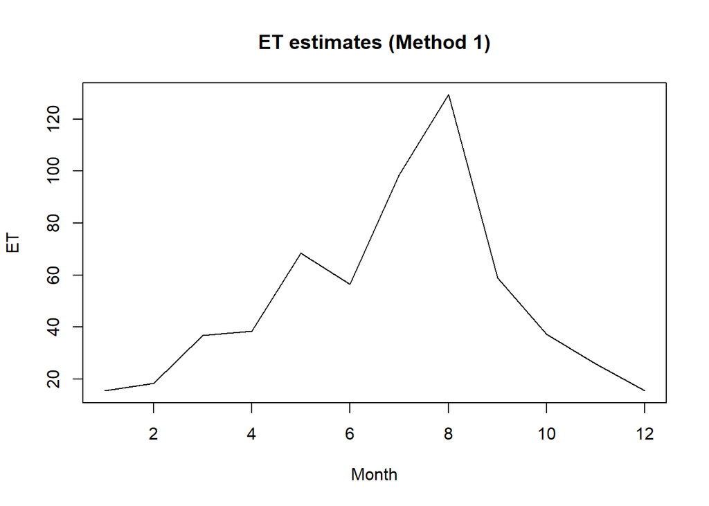

```r
ET_m1 <- with(dat, m1.ET.Sun(FAO.ETo, LAI, P))
plot(1:12, ET_m1, type = "l", xlab = "Month", ylab = "ET",
     main = "ET estimates (Method 1)")
```

Another form of the ET model uses Hamon’s PET model (Sun et al. 2011b):

$$ET = 0.174 · P + 0.502 · PET + 5.31 ·
LAI + 0.0222 · PET · LAI,\quad(2)$$

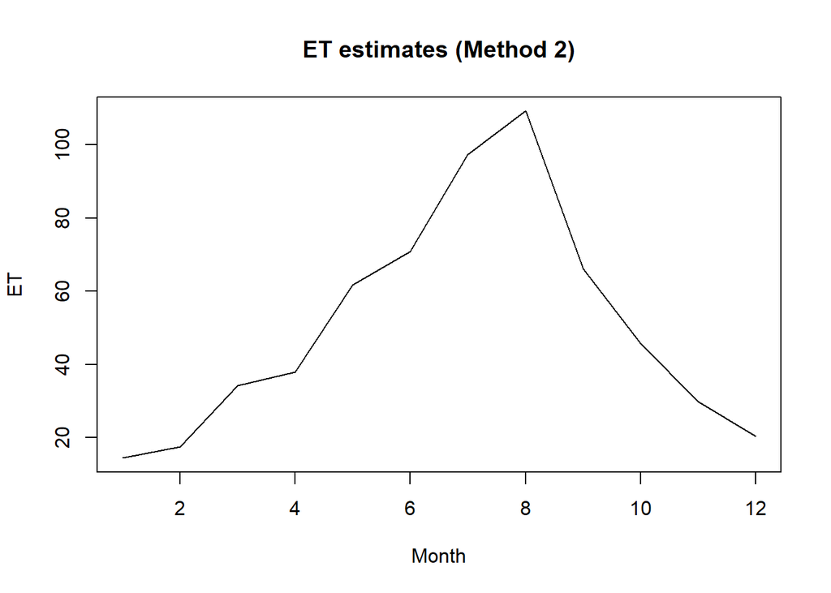

```r
ET_m2 <- with(dat, m2.ET.Sun(HamonPET, LAI, P))
plot(1:12, ET_m2, type = "l", xlab = "Month", ylab = "ET",
     main = "ET estimates (Method 2)")
```

A further model proposed by Fang et al. (2016) is expressed as:

$$ET = 0.42 + 0.74 · PET − 2.73 · VPD + 0.10 · R_n,\quad(3)$$

where $PET$ is monthly potential ET (mm) estimated by Hamon’s method. VPD (kPa) can be estimated from air temperature and relative humidity (See Section 1-2A, B). $R_n$ is net solar radiation (MJ mo<sup>-1</sup> m<sup>-2</sup>).

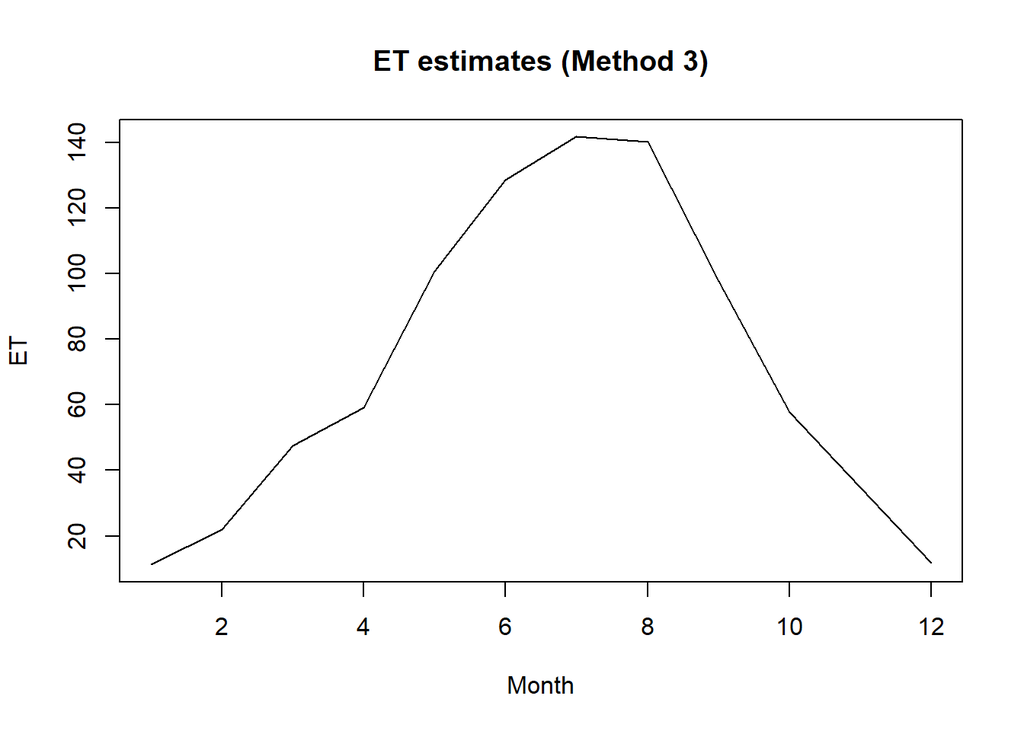

```r
ET_m3 <- with(dat, m3.ET.Fang(HamonPET, VPD, Rn))
plot(1:12, ET_m3, type = "l", xlab = "Month", ylab = "ET",
     main = "ET estimates (Method 3)")
```

Since $R_n$ is rarely available at the regional scale, another model that use precipitation $P$ is expressed as (Fang et al., 2016):

$$ET = −4.79 + 0.75 · PET + 3.92 · LAI + 0.04 · P,\quad(4)$$